# Forecasting-Brazils-Freshwater-Resources-with-Predictive-Modeling

Bryan Z

2023-11-25

## Introduction

James is a junior data analyst working in the sustainability analyst team at Clarkston Consulting, a consulting company in Rio, Brazil. Moreno (director of his floor) requests a forecast report on the Renewable Internal Freshwater Resources of Brazil for the next 10 years.

James is sent to Morticia for the data he will use. Then, he is provided a dataset titled: “Renewable internal freshwater resources per capita (cubic meters)” from the website “Our World in Data”. He is left with a forecast report but not with the variables he could use to produce it.

After doing some research, he finds out that renewable internal freshwater resources (cubic meters) is the internal renewable resources in the country, such as internal river flows and groundwater from rainfall. Besides, he realizes that accounting for this is important for assessing a region’s water security, for sustainable agriculture practices or for early detection of drought conditions since climate change is all over the news nowadays.

James realizes that he should not consider population count for this report since the company requesting the consulting service does not need the forecast based on the population but rather on the consumption on water withdrawals from industrial and agricultural processes.

In order to conduct the forecast, James needs to do some feature engineering for the dataset provided by Morticia. He goes ahead and gets the worldwide population data from the World Bank in order to obtaining the Renewable Internal Freshwater Resources of Brazil without counting capita. Based on the initial dataset, he filters the now ready Renewable Internal Freshwater Resources of Brazil for the years 1989 to 2019 since these are the years stored for Brazil in the dataset provided.

### Feature Engineering for Renewable Internal Freshwater Resources (cubic meters)

```r
# Population Data
population <- read.csv('data/world-population.csv', header = TRUE, skip = 4)

population_long <- population |>
  pivot_longer(
    cols = -c('Country.Name', 'Country.Code', 'Indicator.Name', 'Indicator.Code'),
    names_to = "Year",
    values_to = "Population"
  ) |>
  mutate(Year = as.integer(str_remove(Year, "X")))

filtered_population_long <- population_long |>
  filter(Country.Name == "Brazil" & Year >= 1989 & Year <= 2019) |>
  select(Year, Population)

# view(filtered_population_long)
```

```r
#Renewable Freshwater Data
renew_h2o = read.csv('data/renewable-water-resources-per-capita.csv', header = TRUE)
#view(renew_h2o)

filtered_renew_h2o <- renew_h2o |>
  filter(Entity == "Brazil" & Year >= 1989 & Year <= 2019) |>
  select(Year, Renewable.internal.freshwater.resources.per.capita..cubic.meters.)
#filtered_renew_h2o

#str(filtered_renew_h2o)
```

```r
#Pure Feature Engineering
joined_data <- left_join(filtered_population_long, filtered_renew_h2o, by = "Year")
#joined_data

renew_h2o_clean <- joined_data %>%
  mutate(Renewable.internal.freshwater.resources..cubic.meters =
           Renewable.internal.freshwater.resources.per.capita..cubic.meters. / Population) |>
  select(-Population, -Renewable.internal.freshwater.resources.per.capita..cubic.meters.)

# Create tsibble
ttsibble_data <- as_tsibble(renew_h2o_clean, index = Year)

# Display data
knitr::kable(head(ttsibble_data, 10), caption = "Renewable Freshwater Resources (First 10 Years)")
```

Renewable Freshwater Resources (First 10 Years)

| Year | Renewable.internal.freshwater.resources..cubic.meters |
| --- | --- |
| 1989 | 0.0002584 |
| 1990 | 0.0002492 |
| 1991 | 0.0002408 |
| 1992 | 0.0002329 |
| 1993 | 0.0002255 |
| 1994 | 0.0002184 |
| 1995 | 0.0002117 |
| 1996 | 0.0002053 |
| 1997 | 0.0001993 |
| 1998 | 0.0001935 |

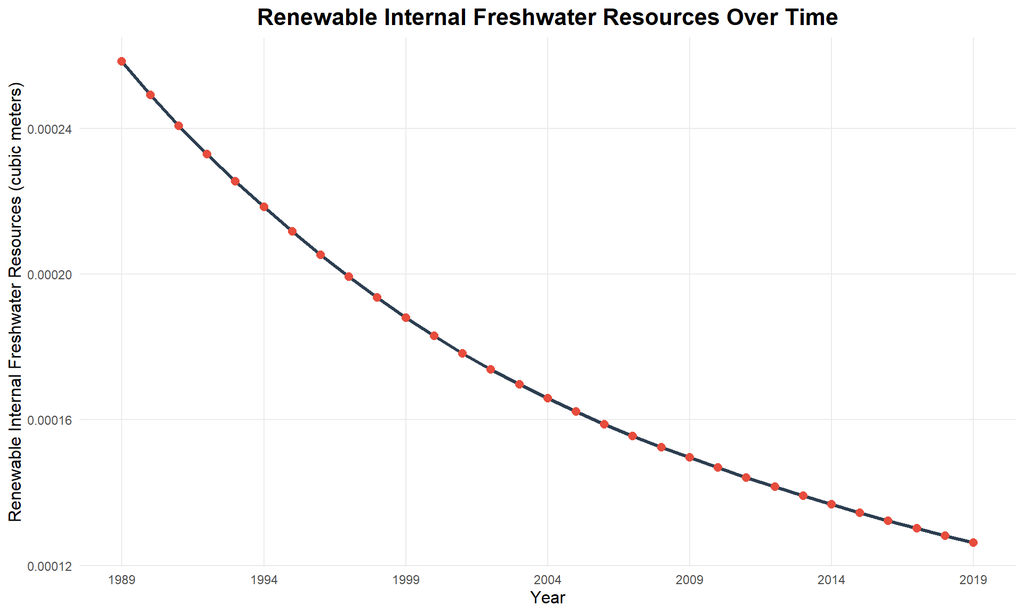

```r
# Plot using ggplot2
ttsibble_data %>%
  as.data.frame() %>%
  ggplot(aes(x = Year, y = Renewable.internal.freshwater.resources..cubic.meters)) +
  geom_line(color = "#2C3E50", size = 1.2) +
  geom_point(color = "#E74C3C", size = 2.5) +
  scale_x_continuous(breaks = seq(1989, 2019, by = 5)) +
  ggtitle("Renewable Internal Freshwater Resources Over Time") +
  xlab("Year") +
  ylab("Renewable Internal Freshwater Resources (cubic meters)") +
  theme_minimal() +
  theme(
    plot.title = element_text(hjust = 0.5, size = 16, face = "bold"),
    axis.title = element_text(size = 12),
    panel.grid.minor = element_blank()
  )
```

```r
# Calculate the annual percentage decrease
initial_count <- 0.0002584340
final_count <- 0.0001262151
initial_year <- 1989
final_year <- 2019

annual_percentage_decrease <- ((final_count / initial_count)^(1 / (final_year - initial_year)) - 1) * -100

cat("Annual Percentage Decrease:", round(annual_percentage_decrease, 2), "%\n")
```

```
## Annual Percentage Decrease: 2.36 %
```

James quickly realizes that the renewable internal freshwater resources of Brazil have been declining over the years, especially since 1989 these resources had a value of 0.0002584340 cubic meters and for 2019 the number shrunk to 0.0001262151 cubic meters. This reflects an annual percentage decrease of 2.36 %.

To continue, James realizes that two of the time series he will explore for the forecast report will be “Number of Cattle” and “Annual freshwater withdrawals” since these time series align with the requirements.

The “Number of Cattle” dataset was extracted from “Our World in Data” and it indicates the number of animals of the species present in the country at the time of enumeration. It includes animals raised either for draft purposes or for meat, eggs and dairy production or kept for breeding.

### Annual Cattle Number

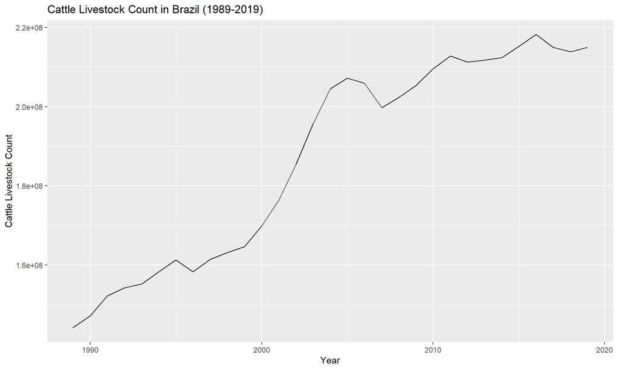

```r
cattle_heads = read.csv('data/cattle-livestock-count-heads.csv', header = TRUE)
#view(cattle_heads)

filtered_cattle_heads <- cattle_heads |>
  filter(Entity == "Brazil" & Year >= 1989 & Year <= 2019) |>
  select(Year, Cattle...00000866....Stocks...005111....animals)

ttsibble_data <- as_tsibble(filtered_cattle_heads, index = Year)
ttsibble_data |> autoplot()+
  ggtitle("Cattle Livestock Count in Brazil (1989-2019)") +
  xlab("Year") +
  ylab("Cattle Livestock Count")
```

```r
ttsibble_data
```

```
## # A tsibble: 31 x 2 [1Y]
##     Year Cattle...00000866....Stocks...005111....animals
##    <int>                                           <int>
##  1  1989                                       144154096
##  2  1990                                       147102320
##  3  1991                                       152135504
##  4  1992                                       154229296
##  5  1993                                       155134080
##  6  1994                                       158243232
##  7  1995                                       161227936
##  8  1996                                       158288544
##  9  1997                                       161416160
## 10  1998                                       163154352
## # ℹ 21 more rows
```

```r
# Calculate the annual percentage increase
initial_count <- 144154096
final_count <- 215008960
initial_year <- 1989
final_year <- 2019

annual_percentage_increase <- ((final_count / initial_count)^(1 / (final_year - initial_year)) - 1) * 100
#print(paste("Annual Percentage Increase: ", round(annual_percentage_increase, 2), "%"))
```

James reflects on the increasing cattle number in Brazil since 1989 to 2019. In 1989 the cattle count was 144154096 and for 2019 it counted for 215008960, meaning an annual percentage increase of 1.34 %.

The other time series,“Annual freshwater withdrawals”, refers to total water withdrawals. It also includes water from desalination plants, agriculture (irrigation and livestock production), industry (cooling thermoelectric plants) and domestic uses (drinking water, municipal use or supply, use for public services, commercial establishments, and homes).

### Annual Freshwater Withdrawals

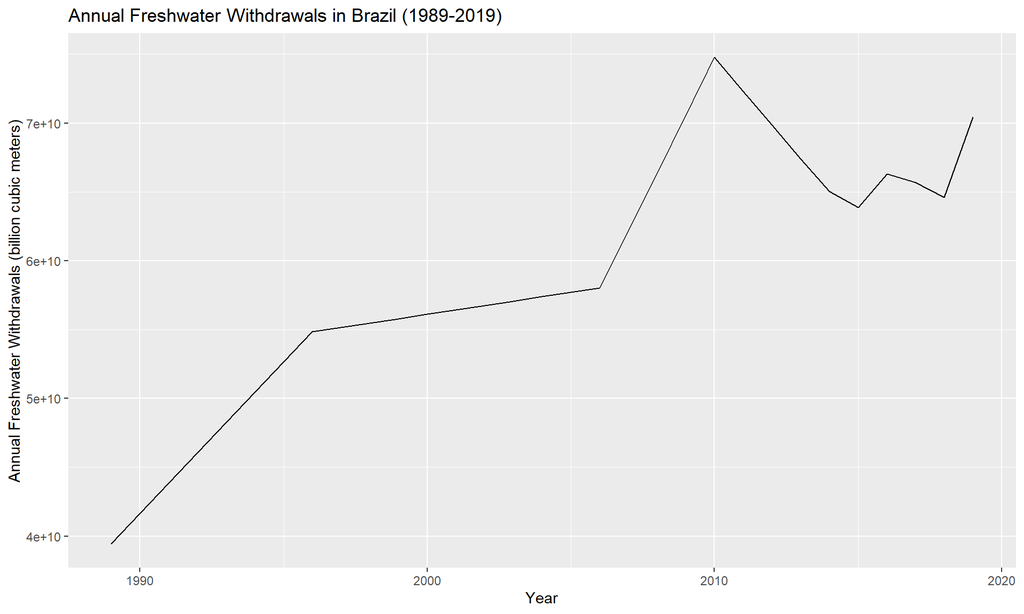

```r
fresh_h2o = read.csv('data/annual-freshwater-withdrawals.csv', header = TRUE)
#view(fresh_h2o)

filtered_fresh_h2o <- fresh_h2o |>
  filter(Entity == "Brazil" & Year >= 1989 & Year <= 2019) |>
  select(Year, Annual.freshwater.withdrawals..total..billion.cubic.meters.)

ttsibble_data <- as_tsibble(filtered_fresh_h2o, index = Year)
ttsibble_data |> autoplot()+
  ggtitle("Annual Freshwater Withdrawals in Brazil (1989-2019)") +
  xlab("Year") +
  ylab("Annual Freshwater Withdrawals (billion cubic meters)")
```

```r
ttsibble_data
```

```
## # A tsibble: 31 x 2 [1Y]
##     Year Annual.freshwater.withdrawals..total..billion.cubic.meters.
##    <int>                                                       <dbl>
##  1  1989                                                 39446667000
##  2  1990                                                 41650000000
##  3  1991                                                 43853333000
##  4  1992                                                 46056667000
##  5  1993                                                 48260000000
##  6  1994                                                 50463333000
##  7  1995                                                 52666668000
##  8  1996                                                 54830000000
##  9  1997                                                 55150000000
## 10  1998                                                 55470000000
## # ℹ 21 more rows
```

```r
# Calculate the annual percentage increase
initial_count <- 39446667000
final_count <- 70430000000
initial_year <- 1989
final_year <- 2019

annual_percentage_increase <- ((final_count / initial_count)^(1 / (final_year - initial_year)) - 1) * 100
#print(paste("Annual Percentage Increase: ", round(annual_percentage_increase, 2), "%"))
```

James reflects on the increasing freshwater withdrawals in Brazil since 1989 to 2019. In 1989 the water withdrawal was 39446667000 cubic meters and for 2019 it was 70430000000 cubic meters, meaning an annual percentage increase of 1.95 %.

Down below, the dataset that James creates with all the time series for his forecast report on the Renewable Internal Freshwater Resources of Brazil for the next 10 years.